# sparkTable: Generating Graphical Tables for Websites and Documents with R

$Debt:$

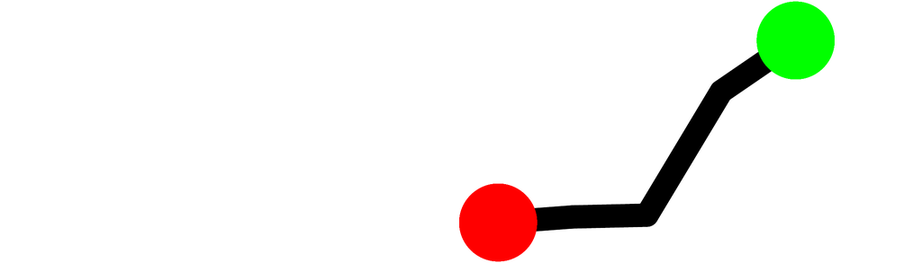

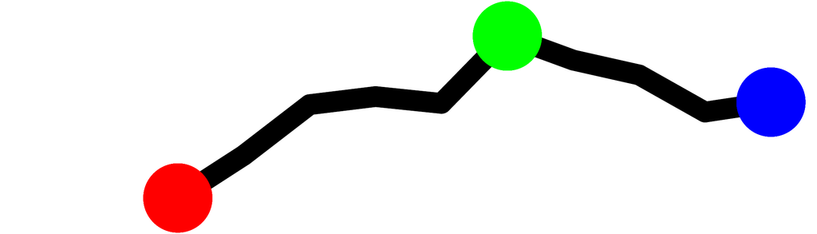

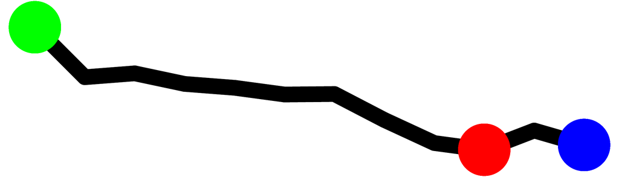

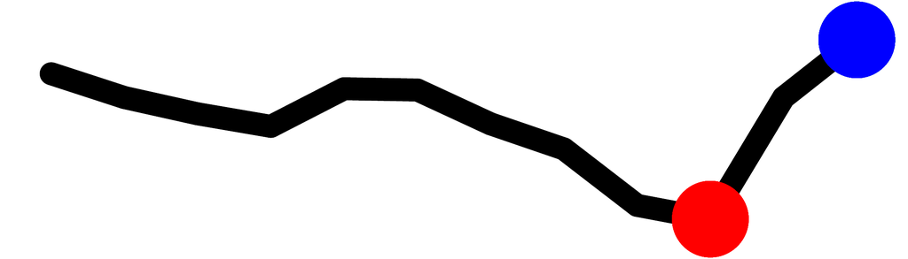

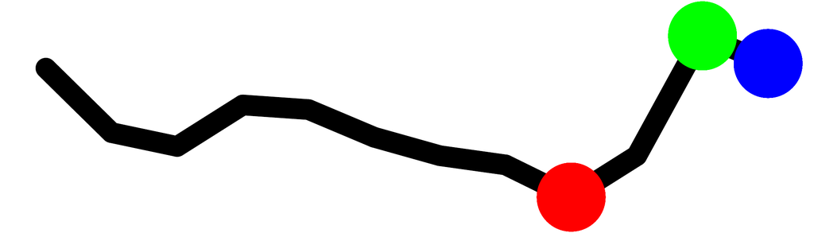

**NL**

**DE**

**DK**

**LT**

**LV**

$Pop:$

$Pop:$

$Pop:$

$Pop:$

$Pop:$

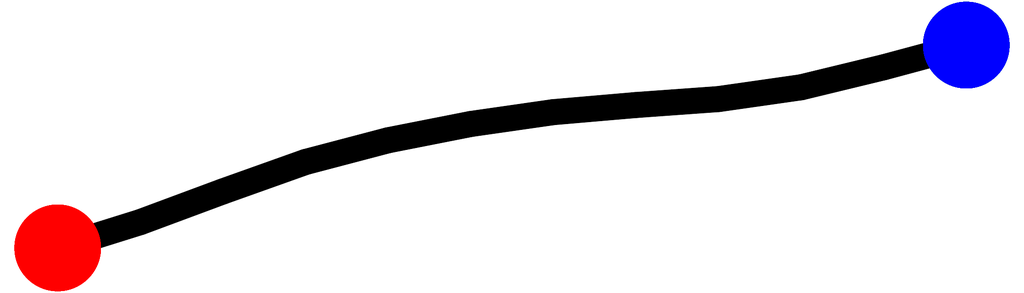

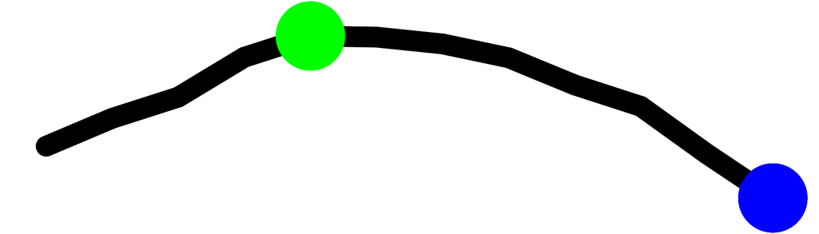

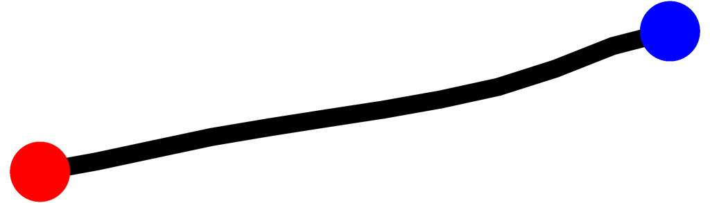

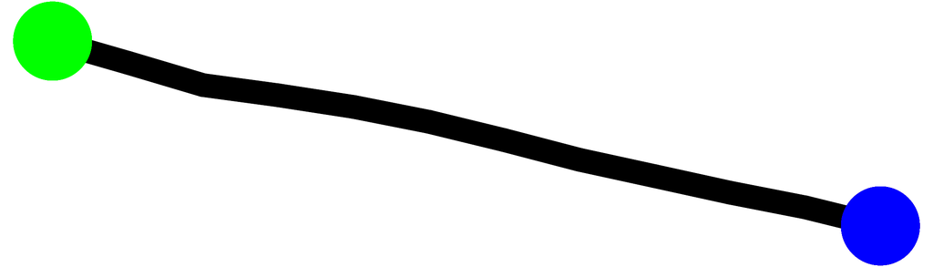

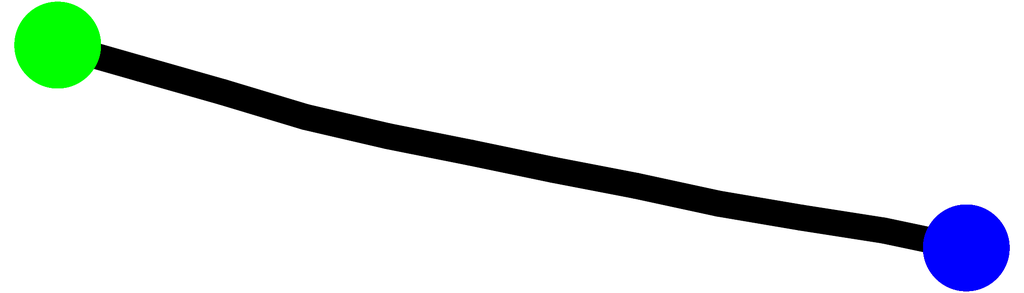

$Debt:$

$Debt:$

$Debt:$

$Debt:$

$Debt:$

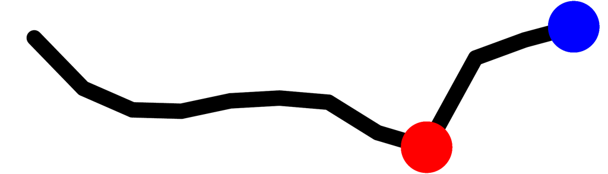

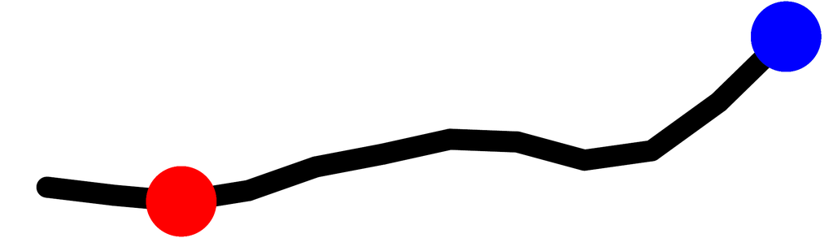

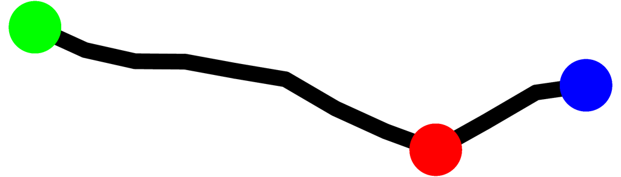

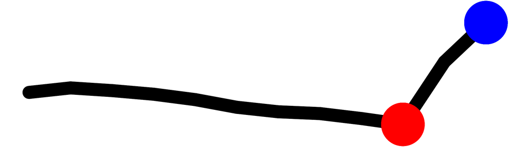

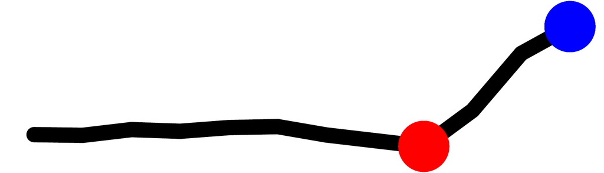

**UK**

**IE**

**BE**

**CZ**

**PL**

**SK**

$Pop:$

$Pop:$

$Pop:$

$Pop:$

$Pop:$

$Pop:$

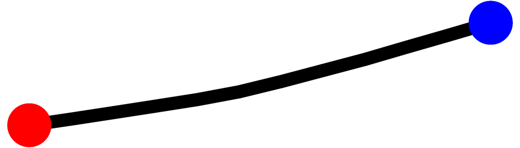

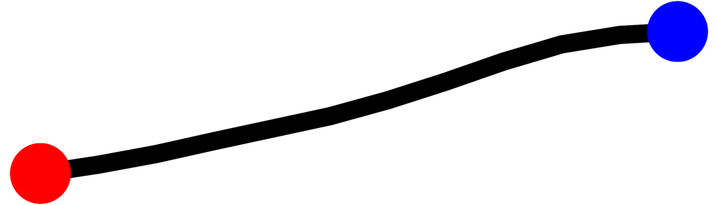

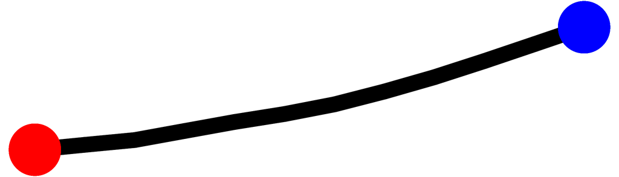

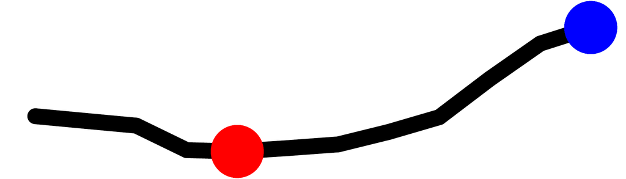

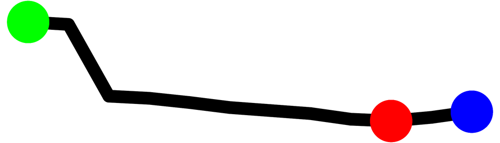

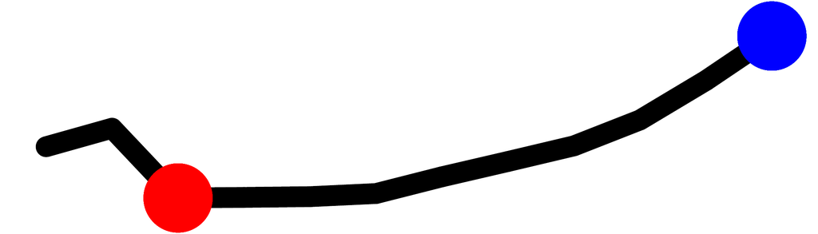

$Debt:$

$Debt:$

$Debt:$

$Debt:$

$Debt:$

$Debt:$

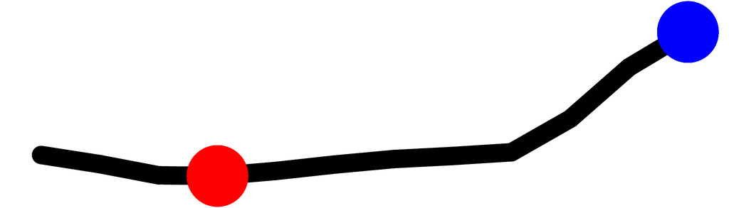

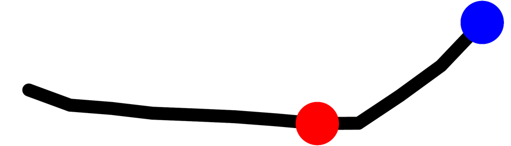

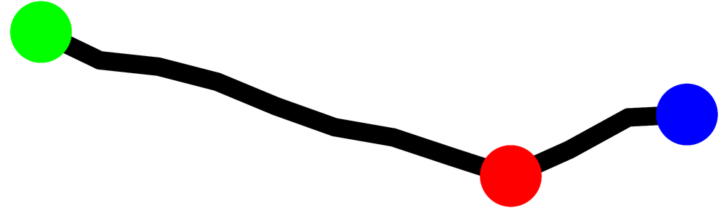

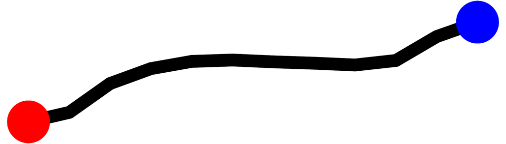

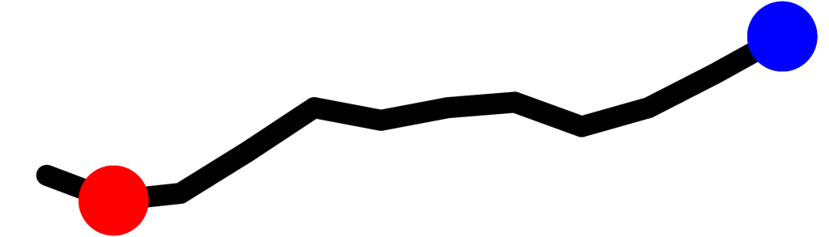

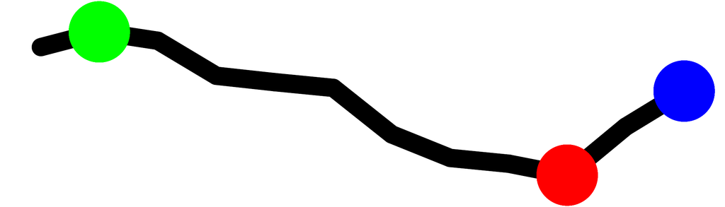

**LU**

**CH**

**LI**

**AT**

**HU**

**RO**

$Pop:$

$Pop:$

$Pop:$

$Pop:$

$Pop:$

$Pop:$

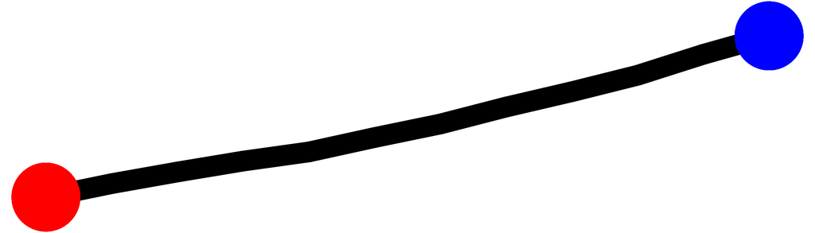

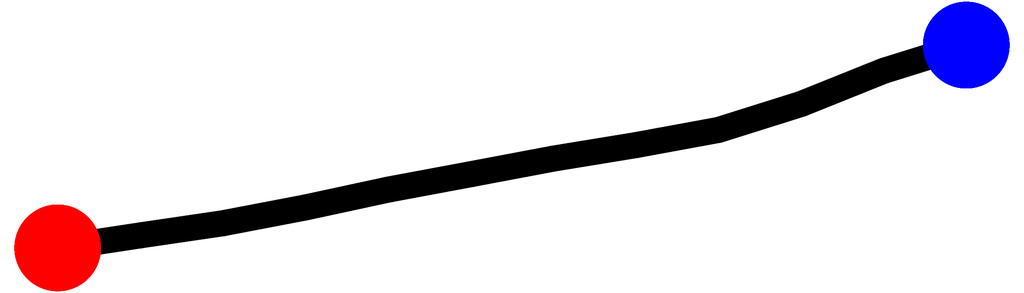

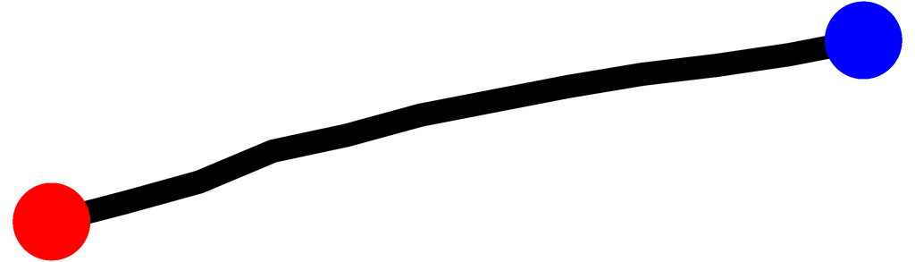

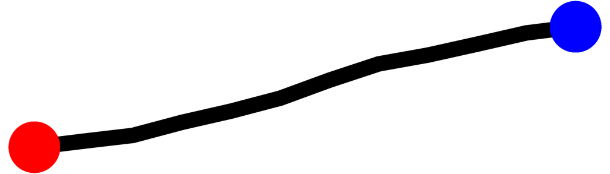

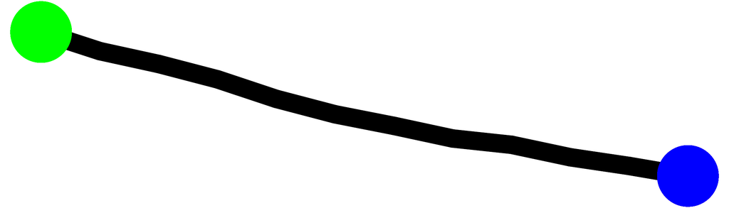

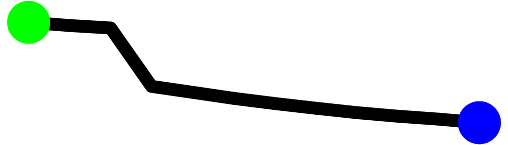

$Debt:$

$Debt:$

$Debt:$

$Debt:$

$Debt:$

$Debt:$

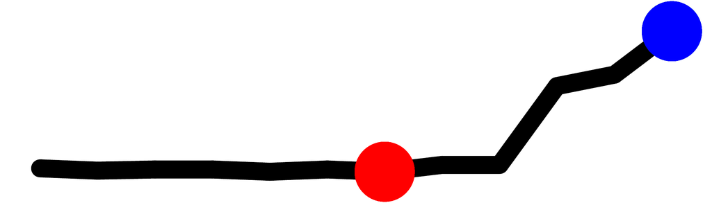

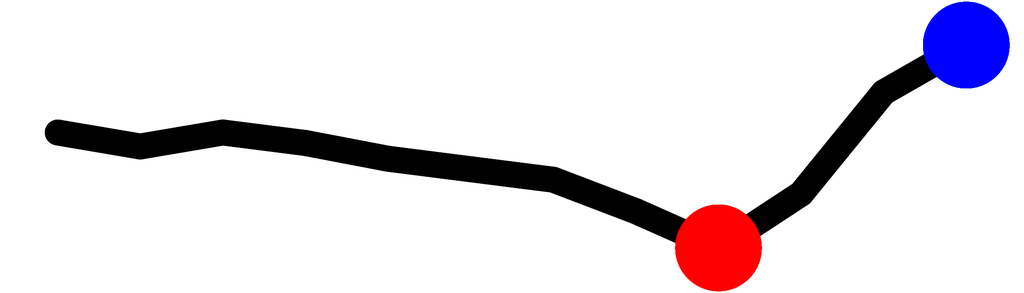

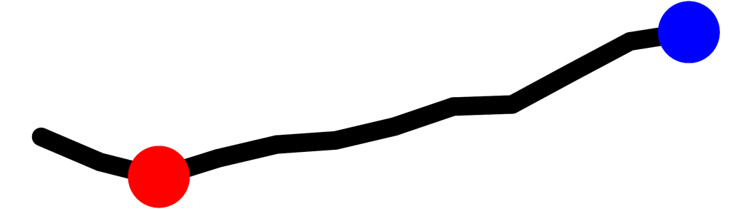

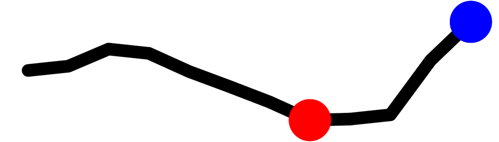

**PT**

**FR**

**SI**

**HR**

**BG**

**TR**

$Pop:$

$Pop:$

$Pop:$

$Pop:$

$Pop:$